# Monte Carlo

Indri ramdani

2024-05-13

```r
library(ggplot2)
library(mvtnorm)
library(MBESS)
```

# Simulasi Uji Hipotesis

Seorang peneliti ingin melihat bagaimana kesalahan tipe $1 (α)$ dari uji t (t test) dan uji peringkat bertanda Wilcoxon (*Wilcoxoan signed-rank test*) [https://sixsigmastudyguide.com/1-sample-wilcoxon-non-parametric-hypothesis-test/] untuk satu populasi pada berbagai ukuran sampel. Hipotesis yang akan diujikan adalah sebagai berikut:

$H_0 : μ = 1500 $

$H_0 : μ ≠ 1500 $

Bangkitan data berdasarkan distribusi $N(μ=1500,σ=200)$, $α=0.05$ dan ulangan sebanyak 10.000. Ukuran sampel yang diteliti adalah 5 sampai 50. Berilah kesimpulan atas hasilnya!

## Mendefinisikan parameter-parameter yang digunakan untuk simulasi

```r
# mendefinisikan ukuran sampel dari 5 saampai 50
n <- seq(5,50)
# mendefinisikan miu distribusi normal
mu0 <- 1500
# mendefinisikan sigma distribusi normal
sigma0 <- 200
# mendefinisikan banyaknya ulangan
num_rep <- 10000
# mendefinisikan alpha
alpha <- 0.05
```

## Mendefinisikan fungsi untuk mengextract p-value dari masing-masing uji (test)

```r
t_test_pvalue <- function(x,alt="two.sided",mu=mu0){
t.test(x, alternative = alt, mu = mu)$p.value
}

wilcox_test_pvalue <- function(x,alt="two.sided",mu=mu0){
wilcox.test(x, alternative = alt, mu = mu)$p.value
}
```

## Menjalankan Simulasi

```r
# membuat objek data.frame dummy untuk menyimpan hasil simulasi
result_sim1 <- data.frame(n=0,alpha_empiris=0,test_name="")
set.seed(2020)
# iterasi simulasi berdasarkan ukuran sampel
for(i in seq_along(n)){
# membangkitan data berdistribusi normal dengan ulangan 10rb
sim_mc_norm <- replicate(num_rep,                     rnorm(n[i],mu0,sigma0))
# menghitung p value uji t dari 10rb data hasil bangkitan
t_test_res <- apply(sim_mc_norm,2,t_test_pvalue)
# menghitung p value uji wilcoxon dari 10rb data hasil bangkitan
wilcox_test_res <- apply(sim_mc_norm,2,wilcox_test_pvalue)
# menghitung alpha empiris dari uji t
t_p_value_sim <- mean(t_test_res<alpha)
# menghitung alpha empiris dari uji wilcoxon
wilcox_p_value_sim <- mean(wilcox_test_res<alpha)
# menyimpan hasil simulasi
result_sim1 <- rbind(result_sim1,list(n[i],t_p_value_sim,"t_test"),
                  list(n[i],wilcox_p_value_sim,"wilcox_test")
)
}
# membuang baris dummy
result_sim1 <- result_sim1[-1,]
```

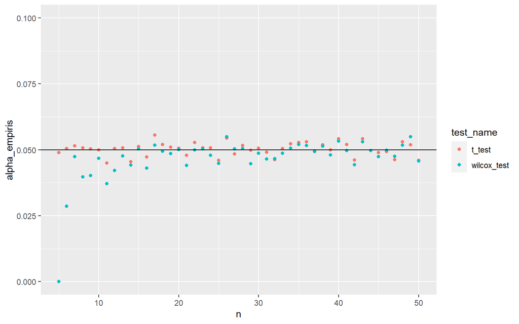

```r
ggplot(data = result_sim1,aes(n,alpha_empiris))+
  geom_point(aes(color=test_name))+geom_hline(yintercept = 0.05)+scale_y_continuous(limits = c(0,0.1))
```

# Pengujian Korelasi

Seorang peneliti ingin melihat bagaimana nilai koefisien korelasi dari metode korelasi pearson dan metode korelasi spearman untuk satu populasi pada berbagai ukuran sampel jika datanya terdapat pencilan. Bangkitan data pencilan dengan cara berikut:

1. Bangkitkan data berdasarkan distribusi multivariate Normal dengan vektor rataan (10,12) dan korelasi 0.85 serta vektor simpangan baku (2,3)
2. Bangkitan outlier pada kedua peubah dengan berdasarkan distribusi N(17,2) sebanyak 20% dari ukuran sampel pada langkah a.
3. Ganti amatan dari hasil bangkitan pada langkah a dengan hasil bangkitan pada langkah b secara acak.

## Langkah 1 (Abstraksi Bangkitan Data)

### Langkah a

```r
set.seed(1212)
# mendefinisikan vektor simpangan baku
sd0 <- c(2,3)
# mendefinisikan matrix korelasi
cor_mat <- matrix(c(1,0.85,0.85,1),nrow=2)
# mengubah matrix korelasi ke kovarians
cov_mat <- MBESS::cor2cov(cor_mat,sd0)
# mendefinisikan vektor rataan
mu_mvn <- c(10,12)
# membangkitkan data berdistribus multivariate normal
x_mvn <- rmvnorm(n=40, mean=c(10,12), sigma=cov_mat)
```

### Langkah b

```r
set.seed(1212)
#membangkitkan data berdasarkan distribusi normal
x1_out <- rnorm(8,17,2)
y1_out <- rnorm(8,17,2)
x1y1_out <-cbind(x1_out,y1_out)
```

### Langkah c

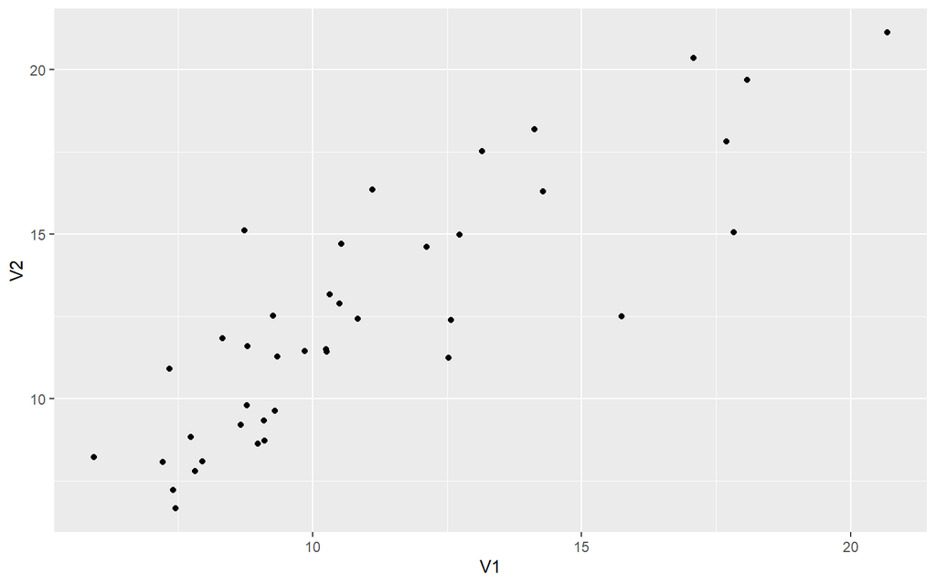

```r
# memilih secara acak amatan yang akan diganti dengan pencilan
index_out <- sample.int(nrow(x_mvn),8)
# mengganti amatan dari langkah a dengan amatan dari langkah b
x_mvn[index_out,] <- x1y1_out
qplot(x = V1,y=V2,data = as.data.frame(x_mvn))
```

## Langkah 2 (Mendefinisikan parameter-parameter yang digunakan untuk simulasi)

```r
# mendefinisikan ukuran sampel yang dikaji
n <- seq(10,100,10)
# mendefinisikan jumlah ulangan
num_rep2 <- 10000
# mendefinisikan vektor simpangan baku
sd0 <- c(2,3)
# mendefinisikan matrix korelasi
cor_mat <- matrix(c(1,0.85,0.85,1),nrow=2)
# mengubah matrix korelasi ke kovarians
cov_mat <- MBESS::cor2cov(cor_mat,sd0)
# mendefinisikan vektor rataan
mu_mvn <- c(10,12)
# mendefinisikan mu dan sigma untuk data pencilan
mu1 <- 17
sigma1 <- 2
```

## Langkah 3 (Mendefinisikan fungsi-fungsi yang dibutuhkan)

```r
# generate multivariate normal dengan pencilan
gen_mvn_out <- function(n0,mu0,sigma0,n1,mu1,sigma1){
x_mvn <- rmvnorm(n=n0, mean=mu0, sigma=sigma0)
x1_out <- rnorm(n1,mu1,sigma1)
y1_out <- rnorm(n1,mu1,sigma1)
x1y1_out <-cbind(x1_out,y1_out)
index_out <- sample.int(nrow(x_mvn),n1)
x_mvn[index_out,] <- x1y1_out
return(x_mvn)
}

# extract koefisien korelasi
cor_res <- function(x_mat,method){
  cor(x_mat[,1],x_mat[,2],method = method)
}
```

## Langkah 4 Menjalankan simulasi

```r
set.seed(1212)
# membuat objek data.frame dummy untuk menyimpan hasil simulasi
result_sim2 <- data.frame(n=0,correlation=0,type="")
for(i in seq_along(n)){
# membangkitan data berdistribusi multivariate normal dengan ulangan 10rb
sim_mc_mvn <- replicate(num_rep2,gen_mvn_out(n0 = n[i],mu_mvn,cov_mat,n1=0.2*n[i],mu1,sigma1),
                        simplify = F)
# menghitung keofisien korelasi pearson dari 10rb data hasil bangkitan
pearson_res <- sapply(sim_mc_mvn,cor_res,method="pearson")
# menghitung keofisien spearman pearson dari 10rb data hasil bangkitan
spearman_res <- sapply(sim_mc_mvn,cor_res,method="spearman")
# menghitung rata-rata koefisien
pearson_sim <- mean(pearson_res)
spearman_sim <- mean(spearman_res)
# menyimpan hasil simulasi
result_sim2 <- rbind(result_sim2,list(n[i],pearson_sim,"pearson"),
                  list(n[i],spearman_sim,"spearman")
)
}
result_sim2 <- result_sim2[-1,]
```

## Langkah 5 Membuat Grafik berdsarkan hasil simulasi

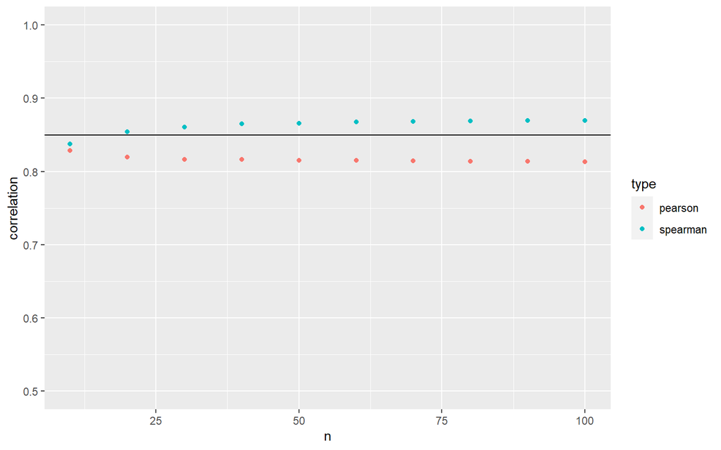

```r
ggplot(data = result_sim2,aes(n,correlation))+
  geom_point(aes(color=type))+geom_hline(yintercept = 0.85)+scale_y_continuous(limits = c(0.5,1))
```

# Pengujian Parameter Regresi

Bangkitkan peubah $Y,X1,X2$ dan $X3$ berdasarkan model regresi linear berganda berikut ini:

$Y=10+3X_1+5X_2+7X_3+ϵ$ dengan mengasumsikan bahwa $ϵ∼N(0,1)$. Banyaknya amatan yang dibangkitkan adalah 1000

## Bangkitkan residual berdasarkan distribusi normal

```r
#banyaknya amatan
n <- 1000
set.seed(12)
epsilon <- rnorm(n,mean = 0,sd = 1)
```

## Bangkitkan peubah penjelas Xi yang saling bebas

```r
set.seed(10)
X <- replicate(3,rnorm(n,mean=0,sd=1.5))
head(X)
```

```
##             [,1]       [,2]        [,3]
## [1,]  0.02811926  1.5750205 -0.46179747
## [2,] -0.27637881  0.4291389  1.13712837
## [3,] -2.05699582  0.3608472 -0.86079512
## [4,] -0.89875157  1.2490578 -1.40811669
## [5,]  0.44181769 -0.3344748 -0.04154899
## [6,]  0.58469145  0.4325163 -1.59937298
```

Pembangkitan peubah penjelas $X_i$ dapat dilakukan juga dengan fungsi **mvnorm** jika ingin melakukan simulasi multikolinearitas.

## Bangkitkan peubah respon Y dengan menggunakan model regresi

```r
betas <- matrix(c(10,3,5,7),nrow = 4,ncol = 1)
Xgab <- cbind(1,X)

Y <- Xgab%*%betas+epsilon

dataRegresi <- data.frame(Y,X)
colnames(dataRegresi) <- c("Y","X1","X2","X3")
head(dataRegresi)
```

|  | Y | X1 | X2 | X3 |
| --- | --- | --- | --- | --- |
| 1 | 13.246310 | 0.02811926 | 1.5750205 | -0.46179747 |
| 2 | 20.853626 | -0.27637881 | 0.4291389 | 1.13712837 |
| 3 | -1.349062 | -2.05699582 | 0.3608472 | -0.86079512 |
| 4 | 2.772212 | -0.89875157 | 1.2490578 | -1.40811669 |
| 5 | 7.364594 | 0.44181769 | -0.3344748 | -0.04154899 |
| 6 | 2.448749 | 0.58469145 | 0.4325163 | -1.59937298 |

** Note : ** sintaks **Xgab <- cbind(1,X)** digunakan untuk menggabungkan peubah penjelas yang ada di matrik $X$ dengan vektor yang isinya 1. Vektor ini digunakan sebagai pengkali konstanta model (dalam hal ini bernilai 10).

Untuk membuktikan bahwa bangkitan kita benar, maka kita akan memodelkan data tersebut dengan fungsi lm yang ada id R.

```r
modelRegresi <- lm(Y~.,data = dataRegresi)
summary(modelRegresi)
```

```
##
## Call:
## lm(formula = Y ~ ., data = dataRegresi)
##
## Residuals:
##     Min      1Q  Median      3Q     Max
## -3.0364 -0.6052 -0.0207  0.6087  3.1774
##
## Coefficients:
##             Estimate Std. Error t value Pr(>|t|)
## (Intercept)  9.97484    0.03033   328.8   <2e-16 ***
## X1           2.97225    0.02042   145.6   <2e-16 ***
## X2           4.97282    0.01939   256.5   <2e-16 ***
## X3           7.00493    0.01989   352.2   <2e-16 ***
## ---
## Signif. codes:  0 '***' 0.001 '**' 0.01 '*' 0.05 '.' 0.1 ' ' 1
##
## Residual standard error: 0.9589 on 996 degrees of freedom
## Multiple R-squared:  0.9955, Adjusted R-squared:  0.9954
## F-statistic: 7.275e+04 on 3 and 996 DF,  p-value: < 2.2e-16
```

Berdasarkan output regresi diatas, nilai koefisien regresi yang dihasilkan mendekati nilai koefisien regresi yang kita bangkitkan. Hal ini membuktikan bahwa data sudah sesuai dengan model regresi yang kita inginkan.

## Menghitung rata-rata dan simpangan baku dari masing-masing koefisien regresi.

```r
#banyaknya amatan
n <- 1000
ulangan <- 100

# membuat tempat penyimpanan
# koefisien tiap ulangan
koefisien_ulangan <- NULL

set.seed(13)
for(i in seq(ulangan)){
epsilon <- rnorm(n,mean = 0,sd = 1)
X <- replicate(3,rnorm(n,mean=0,sd=1.5))
Xgab <- cbind(1,X)
Y <- Xgab%*%betas+epsilon
dataRegresi <- data.frame(Y,X)
colnames(dataRegresi) <- c("Y","X1","X2","X3")
modelRegresi <- lm(Y~.,data = dataRegresi)
# rbind digunakan untuk menggabungkan baris
koefisien_ulangan <- rbind(koefisien_ulangan,coef(modelRegresi))
}
head(koefisien_ulangan)
```

```
##      (Intercept)       X1       X2       X3
## [1,]    9.998451 2.997131 4.961536 7.019022
## [2,]    9.999899 2.981410 5.012151 6.977783
## [3,]    9.971732 2.986735 4.992031 7.019945
## [4,]    9.940730 3.013790 5.006416 7.003125
## [5,]   10.029303 3.033154 5.009336 6.972909
## [6,]   10.008416 3.019092 5.010800 6.999371
```

```r
#menghitung mean dari setiap koefisien
colMeans(koefisien_ulangan)
```

```
## (Intercept)          X1          X2          X3
##    9.997236    3.002950    5.000115    7.001103
```

```r
#menghitung sd dari setiap koefisien
apply(koefisien_ulangan,2,sd)
```

```
## (Intercept)          X1          X2          X3
##  0.02972359  0.01960207  0.01923794  0.02379381
```

# TUGAS UAS

1. Jika data diasumsikan tidak normal bagaimana ukuran sampel berpengaruh kesalahan tipe 1 pada uji hipotesis pada contoh 1? Silahkan buat simulasi berdaasarkan asumsi sebaran berikut:
1. 50% sebaran normal $N(0,1)$ dan 50% sebaran chi-square $χ2(df=1)$
2. 50% sebaran chi-square $χ2(df=1)$ dan 50% dengan chi-square $χ2(df=3)$
3. 25% sebaran chi-square $χ2(df=1)$. 25% dengan chi-square $χ2(df=3)$, 25% sebaran normal N(0,1)dan 25% sebaran normal N(3,1.5)
2. Buatlah simulasi statistika untuk menunjukkan pengaruh banyaknya amatan dan tidak terpenuhinya asumsi sebaran normal terhadap pengujian hipotesis di one-way ANOVA! Cobalah dengan sebaran yang ada di **Tugas 1**

   (Hint: model linear pada rancangan acak lengkap untuk membangkitkan data dalam simulasi ini. )
3. Buatlah langkah-langkah pembangkitan data agar bisa digunakan untuk menyelidiki asumsi ragam homogen dalam model regresi! Realiasikan langkah-langkahmu tersebut dalam R!